# DSTI Metaheuristic Assignment2 at 2019/06/10 - Exercise 3

# Ex3-0. Warming up

## Ex3-0.1. Import Supportive Libraries

```r
library(dplyr)
library(ggplot2)
```

## Ex3-0.2. Define Functions to Be Optimized

```r
#Banana Function (https://en.wikipedia.org/wiki/Rosenbrock_function)
banana <- function(x1,x2){
    100*(x2-x1^2)^2+(1-x1)^2
}

#Eggcrate Function (https://www.al-roomi.org/benchmarks/unconstrained/2-dimensions/122-egg-crate-function)
eggcrate <- function(x1,x2){
    x1^2+x2^2+25*(sin(x1)^2 + sin(x2)^2)
}

#Golinsky's Speed Reducer (https://arc.aiaa.org/doi/abs/10.2514/2.1984)
golSR <- function(x1,x2,x3,x4,x5,x6,x7){
  0.7854*x1*x2^2*(3.3333*x3^2 + 14.9334*x3 - 43.0934) - 1.5079*x1*(x6^2 + x7^2)  + 7.477*(x6^3 + x7^3) + 0.7854*(x4*x6^2+x5*x7^2)
}
```

```r
constGSR1 <- function(x1, x2, x3, x4, x5, x6, x7) {
     1- 27/x1/x2**2/x3
}

constGSR2 <- function(x1, x2, x3, x4, x5, x6, x7) {
     1 - 397.5/x1/x2**2/x3**2
}

constGSR3 <- function(x1, x2, x3, x4, x5, x6, x7) {
     1 - 1.93/x2/x3*x4**3/x6**4
}

constGSR4 <- function(x1, x2, x3, x4, x5, x6, x7) {
     1 - 1.93/x2/x3*x5**3/x7**4
}

constGSR5 <- function(x1, x2, x3, x4, x5, x6, x7) {
     1 - ( ( (745*x4/x2/x3)**2 + 16.9*10**6 )**0.5 / (110*x6**3))
}

constGSR6 <- function(x1, x2, x3, x4, x5, x6, x7) {
     1 - ( ( (745*x5/x2/x3)**2 + 157.5*10**6 )**0.5 / (85*x7**3))
}

constGSR7 <- function(x1, x2, x3, x4, x5, x6, x7) {
     1 - x2*x3 / 40
}

constGSR8 <- function(x1, x2, x3, x4, x5, x6, x7) {
     1 - 5*x2/x1
}

constGSR9 <- function(x1, x2, x3, x4, x5, x6, x7) {
     1 - x1/12*x2
}

constGSR24 <- function(x1, x2, x3, x4, x5, x6, x7) {
     1 - (1.5*x6 + 1.9)/x4
}

constGSR25 <- function(x1, x2, x3, x4, x5, x6, x7) {
     1 - (1.1*x7 + 1.9)/x5
}

constGSR10 <- function(x1, x2, x3, x4, x5, x6, x7) {
     x1 - 2.6
}

constGSR11 <- function(x1, x2, x3, x4, x5, x6, x7) {
     3.6 - x1
}

constGSR12 <- function(x1, x2, x3, x4, x5, x6, x7) {
     x2 - 0.7
}

constGSR13 <- function(x1, x2, x3, x4, x5, x6, x7) {
     0.8 - x2
}

constGSR14 <- function(x1, x2, x3, x4, x5, x6, x7) {
     x3 - 17
}

constGSR15 <- function(x1, x2, x3, x4, x5, x6, x7) {
     28 - x3
}

constGSR16 <- function(x1, x2, x3, x4, x5, x6, x7) {
     x4 - 7.3
}

constGSR17 <- function(x1, x2, x3, x4, x5, x6, x7) {
     8.3 - x4
}

constGSR18 <- function(x1, x2, x3, x4, x5, x6, x7) {
     x5 - 7.3
}

constGSR19 <- function(x1, x2, x3, x4, x5, x6, x7) {
     8.3 - x5
}

constGSR20 <- function(x1, x2, x3, x4, x5, x6, x7) {
     x6 - 2.9
}

constGSR21 <- function(x1, x2, x3, x4, x5, x6, x7) {
     3.9 - x6
}

constGSR22 <- function(x1, x2, x3, x4, x5, x6, x7) {
     x7 - 5.0
}

constGSR23 <- function(x1, x2, x3, x4, x5, x6, x7) {
     5.9 - x7
}

constGSR <- function(x1, x2, x3, x4, x5, x6, x7) {
    if (
                (constGSR1(x1, x2, x3, x4, x5, x6, x7) >= 0)
                &&
                (constGSR2(x1, x2, x3, x4, x5, x6, x7) >= 0)
                &&
                (constGSR3(x1, x2, x3, x4, x5, x6, x7) >= 0)
                &&
                (constGSR4(x1, x2, x3, x4, x5, x6, x7) >= 0)
                &&
                (constGSR5(x1, x2, x3, x4, x5, x6, x7) >= 0)
                &&
                (constGSR6(x1, x2, x3, x4, x5, x6, x7) >= 0)
                &&
                (constGSR7(x1, x2, x3, x4, x5, x6, x7) >= 0)
                &&
                (constGSR8(x1, x2, x3, x4, x5, x6, x7) >= 0)
                &&
                (constGSR9(x1, x2, x3, x4, x5, x6, x7) >= 0)
                &&
                (constGSR10(x1, x2, x3, x4, x5, x6, x7) >= 0)
                &&
                (constGSR11(x1, x2, x3, x4, x5, x6, x7) >= 0)
                &&
                (constGSR12(x1, x2, x3, x4, x5, x6, x7) >= 0)
                &&
                (constGSR13(x1, x2, x3, x4, x5, x6, x7) >= 0)
                &&
                (constGSR14(x1, x2, x3, x4, x5, x6, x7) >= 0)
                &&
                (constGSR15(x1, x2, x3, x4, x5, x6, x7) >= 0)
                &&
                (constGSR16(x1, x2, x3, x4, x5, x6, x7) >= 0)
                &&
                (constGSR17(x1, x2, x3, x4, x5, x6, x7) >= 0)
                &&
                (constGSR18(x1, x2, x3, x4, x5, x6, x7) >= 0)
                &&
                (constGSR19(x1, x2, x3, x4, x5, x6, x7) >= 0)
                &&
                (constGSR20(x1, x2, x3, x4, x5, x6, x7) >= 0)
                &&
                (constGSR21(x1, x2, x3, x4, x5, x6, x7) >= 0)
                &&
                (constGSR22(x1, x2, x3, x4, x5, x6, x7) >= 0)
                &&
                (constGSR23(x1, x2, x3, x4, x5, x6, x7) >= 0)
                &&
                (constGSR24(x1, x2, x3, x4, x5, x6, x7) >= 0)
                &&
                (constGSR25(x1, x2, x3, x4, x5, x6, x7) >= 0)
            ) {
        0
    } else {
        1
    }
}

constls <- c(constGSR1, constGSR2, constGSR3, constGSR4, constGSR5, constGSR6, constGSR7,
             constGSR8, constGSR9, constGSR10, constGSR11, constGSR12, constGSR13,
             constGSR14, constGSR15, constGSR16, constGSR17, constGSR18, constGSR19,
             constGSR20, constGSR21, constGSR22, constGSR23, constGSR24, constGSR25)

constGSRcnt <- function(x1, x2, x3, x4, x5, x6, x7) {
  (constGSR1(x1, x2, x3, x4, x5, x6, x7) >= 0)*1 +
  (constGSR2(x1, x2, x3, x4, x5, x6, x7) >= 0)*1 +
  (constGSR3(x1, x2, x3, x4, x5, x6, x7) >= 0)*1 +
  (constGSR4(x1, x2, x3, x4, x5, x6, x7) >= 0)*1 +
  (constGSR5(x1, x2, x3, x4, x5, x6, x7) >= 0)*1 +
  (constGSR6(x1, x2, x3, x4, x5, x6, x7) >= 0)*1 +
  (constGSR7(x1, x2, x3, x4, x5, x6, x7) >= 0)*1 +
  (constGSR8(x1, x2, x3, x4, x5, x6, x7) >= 0)*1 +
  (constGSR9(x1, x2, x3, x4, x5, x6, x7) >= 0)*1 +
  (constGSR10(x1, x2, x3, x4, x5, x6, x7) >= 0)*1 +
  (constGSR11(x1, x2, x3, x4, x5, x6, x7) >= 0)*1 +
  (constGSR12(x1, x2, x3, x4, x5, x6, x7) >= 0)*1 +
  (constGSR13(x1, x2, x3, x4, x5, x6, x7) >= 0)*1 +
  (constGSR14(x1, x2, x3, x4, x5, x6, x7) >= 0)*1 +
  (constGSR15(x1, x2, x3, x4, x5, x6, x7) >= 0)*1 +
  (constGSR16(x1, x2, x3, x4, x5, x6, x7) >= 0)*1 +
  (constGSR17(x1, x2, x3, x4, x5, x6, x7) >= 0)*1 +
  (constGSR18(x1, x2, x3, x4, x5, x6, x7) >= 0)*1 +
  (constGSR19(x1, x2, x3, x4, x5, x6, x7) >= 0)*1 +
  (constGSR20(x1, x2, x3, x4, x5, x6, x7) >= 0)*1 +
  (constGSR21(x1, x2, x3, x4, x5, x6, x7) >= 0)*1 +
  (constGSR22(x1, x2, x3, x4, x5, x6, x7) >= 0)*1 +
  (constGSR23(x1, x2, x3, x4, x5, x6, x7) >= 0)*1 +
  (constGSR24(x1, x2, x3, x4, x5, x6, x7) >= 0)*1 +
  (constGSR25(x1, x2, x3, x4, x5, x6, x7) >= 0)*1
}

constGSRdist <- function(x1, x2, x3, x4, x5, x6, x7) {
  min(0,constGSR1(x1, x2, x3, x4, x5, x6, x7)) +
  min(0,constGSR2(x1, x2, x3, x4, x5, x6, x7)) +
  min(0,constGSR3(x1, x2, x3, x4, x5, x6, x7)) +
  min(0,constGSR4(x1, x2, x3, x4, x5, x6, x7)) +
  min(0,constGSR5(x1, x2, x3, x4, x5, x6, x7)) +
  min(0,constGSR6(x1, x2, x3, x4, x5, x6, x7)) +
  min(0,constGSR7(x1, x2, x3, x4, x5, x6, x7)) +
  min(0,constGSR8(x1, x2, x3, x4, x5, x6, x7)) +
  min(0,constGSR9(x1, x2, x3, x4, x5, x6, x7)) +
  min(0,constGSR10(x1, x2, x3, x4, x5, x6, x7)) +
  min(0,constGSR11(x1, x2, x3, x4, x5, x6, x7)) +
  min(0,constGSR12(x1, x2, x3, x4, x5, x6, x7)) +
  min(0,constGSR13(x1, x2, x3, x4, x5, x6, x7)) +
  min(0,constGSR14(x1, x2, x3, x4, x5, x6, x7)) +
  min(0,constGSR15(x1, x2, x3, x4, x5, x6, x7)) +
  min(0,constGSR16(x1, x2, x3, x4, x5, x6, x7)) +
  min(0,constGSR17(x1, x2, x3, x4, x5, x6, x7)) +
  min(0,constGSR18(x1, x2, x3, x4, x5, x6, x7)) +
  min(0,constGSR19(x1, x2, x3, x4, x5, x6, x7)) +
  min(0,constGSR20(x1, x2, x3, x4, x5, x6, x7)) +
  min(0,constGSR21(x1, x2, x3, x4, x5, x6, x7)) +
  min(0,constGSR22(x1, x2, x3, x4, x5, x6, x7)) +
  min(0,constGSR23(x1, x2, x3, x4, x5, x6, x7)) +
  min(0,constGSR24(x1, x2, x3, x4, x5, x6, x7)) +
  min(0,constGSR25(x1, x2, x3, x4, x5, x6, x7))
}
```

```r
#Test functions
# golSR(3.5, 0.7, 17, 8.1, 7.74, 3.353, 5.29)       ----> 3004.798
# constGSR(3.5, 0.7, 17, 8.1, 7.74, 3.353, 5.29)    ----> 0
#
# constGSR1(3.5, 0.7, 17, 8.1, 7.74, 3.353, 5.29)   ----> 0.07391528
# constGSR2(3.5, 0.7, 17, 8.1, 7.74, 3.353, 5.29)   ----> 0.1979985
# constGSR3(3.5, 0.7, 17, 8.1, 7.74, 3.353, 5.29)   ----> 0.3180835
# constGSR4(3.5, 0.7, 17, 8.1, 7.74, 3.353, 5.29)   ----> 0.9039692
# constGSR5(3.5, 0.7, 17, 8.1, 7.74, 3.353, 5.29)   ----> 0.001083367
# constGSR6(3.5, 0.7, 17, 8.1, 7.74, 3.353, 5.29)   ----> 0.001891349
# constGSR7(3.5, 0.7, 17, 8.1, 7.74, 3.353, 5.29)   ----> 0.7025
# constGSR8(3.5, 0.7, 17, 8.1, 7.74, 3.353, 5.29)   ----> 0
# constGSR9(3.5, 0.7, 17, 8.1, 7.74, 3.353, 5.29)   ----> 0.7958333
# constGSR24(3.5, 0.7, 17, 8.1, 7.74, 3.353, 5.29)  ----> 0.1445062
# constGSR25(3.5, 0.7, 17, 8.1, 7.74, 3.353, 5.29)  ----> 0.002713178

# constGSRcnt(3.5, 0.7, 17, 8.1, 7.74, 3.353, 5.29)   ----> 25
# constGSRdist(3.5, 0.7, 17, 8.1, 7.74, 3.353, 5.29)  ----> 0
```

# Ex3-1. Genetic Algorithm

```r
library(GA)
```

## Ex3-1.1. Banana Function

### Ex3-1.1.1. One Simulation

Parameters used:

- Initial population Size: 20 (default: # of decision variables * 10)
- Nb of iterations: 100 (default)
- Cross over rate: 0.5 (default)
- Mutation rate: 0 (default)
- Elitism number: 0 (default)

NOTE:

- Since GA library assumes the objective function is to maximize, the value was negativated.

```r
set.seed(1)
GA.banana <- de(type = "real-valued", fitness = function(x) -banana(x[1],x[2]), lower = c(-5,-5), upper = c(5,5))
```

```
DE | iter = 1 | Mean = -11172.42139 | Best =     -7.93981
DE | iter = 2 | Mean = -2401.59531 | Best =    -3.86748
DE | iter = 3 | Mean = -1744.26101 | Best =    -3.86748
DE | iter = 4 | Mean = -813.24722 | Best =   -3.86748
DE | iter = 5 | Mean = -221.604130 | Best =   -1.186693
DE | iter = 6 | Mean = -115.784066 | Best =   -1.186693
DE | iter = 7 | Mean = -99.041954 | Best =  -1.186693
DE | iter = 8 | Mean = -67.562446 | Best =  -1.186693
DE | iter = 9 | Mean = -49.287361 | Best =  -1.186693
DE | iter = 10 | Mean = -42.1307303 | Best =  -0.2762504
DE | iter = 11 | Mean = -37.0997442 | Best =  -0.2762504
DE | iter = 12 | Mean = -24.4019908 | Best =  -0.2762504
DE | iter = 13 | Mean = -7.8520463 | Best = -0.1190037
DE | iter = 14 | Mean = -7.2639204 | Best = -0.1190037
DE | iter = 15 | Mean = -5.8362295 | Best = -0.1190037
DE | iter = 16 | Mean = -2.8128189 | Best = -0.1190037
DE | iter = 17 | Mean = -2.76220169 | Best = -0.07152792
DE | iter = 18 | Mean = -2.73499325 | Best = -0.07152792
DE | iter = 19 | Mean = -2.43004654 | Best = -0.07152792
DE | iter = 20 | Mean = -2.29037428 | Best = -0.07152792
DE | iter = 21 | Mean = -2.29037428 | Best = -0.07152792
DE | iter = 22 | Mean = -2.21834956 | Best = -0.07152792
DE | iter = 23 | Mean = -2.19450053 | Best = -0.07152792
DE | iter = 24 | Mean = -1.95130833 | Best = -0.07152792
DE | iter = 25 | Mean = -1.942479150 | Best = -0.003524073
DE | iter = 26 | Mean = -1.366941015 | Best = -0.003524073
DE | iter = 27 | Mean = -1.333582585 | Best = -0.003524073
DE | iter = 28 | Mean = -1.333582585 | Best = -0.003524073
DE | iter = 29 | Mean = -0.996150334 | Best = -0.003524073
DE | iter = 30 | Mean = -0.753924705 | Best = -0.003524073
DE | iter = 31 | Mean = -0.752031287 | Best = -0.003524073
DE | iter = 32 | Mean = -0.594779748 | Best = -0.003524073
DE | iter = 33 | Mean = -0.577264032 | Best = -0.003524073
DE | iter = 34 | Mean = -0.381431130 | Best = -0.003524073
DE | iter = 35 | Mean = -0.305245685 | Best = -0.003524073
DE | iter = 36 | Mean = -0.300335536 | Best = -0.003524073
DE | iter = 37 | Mean = -0.208769970 | Best = -0.003524073
DE | iter = 38 | Mean = -0.185231801 | Best = -0.003524073
DE | iter = 39 | Mean = -0.166928325 | Best = -0.003524073
DE | iter = 40 | Mean = -0.148089358 | Best = -0.003524073
```

[output cut: 45 more lines]

```
DE | iter = 86 | Mean = -3.944805e-05 | Best = -2.039396e-06
DE | iter = 87 | Mean = -3.498196e-05 | Best = -2.039396e-06
DE | iter = 88 | Mean = -3.157301e-05 | Best = -2.039396e-06
DE | iter = 89 | Mean = -2.344158e-05 | Best = -2.039396e-06
DE | iter = 90 | Mean = -2.329926e-05 | Best = -2.039396e-06
DE | iter = 91 | Mean = -2.125585e-05 | Best = -2.039396e-06
DE | iter = 92 | Mean = -1.771007e-05 | Best = -2.039396e-06
DE | iter = 93 | Mean = -1.653025e-05 | Best = -2.039396e-06
DE | iter = 94 | Mean = -1.527103e-05 | Best = -2.991388e-07
DE | iter = 95 | Mean = -1.134824e-05 | Best = -2.991388e-07
DE | iter = 96 | Mean = -1.110361e-05 | Best = -2.991388e-07
DE | iter = 97 | Mean = -9.678105e-06 | Best = -2.991388e-07
DE | iter = 98 | Mean = -8.440921e-06 | Best = -2.991388e-07
DE | iter = 99 | Mean = -8.209781e-06 | Best = -2.991388e-07
DE | iter = 100 | Mean = -7.880244e-06 | Best = -2.991388e-07
```

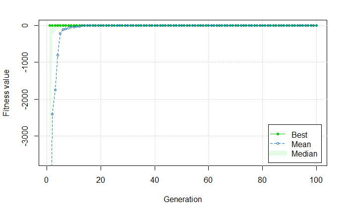

```r
plot(GA.banana)
```

### Ex3-1.1.2. Ten Simulations

```r
time0 <- Sys.time()
for (i in 1:10){
  set.seed(i+1)
  GA.banana.t <- de(type = "real-valued", fitness = function(x) -banana(x[1],x[2]), lower = c(-5,-5), upper = c(5,5),monitor=F)
  if (i==1) {
    res <- GA.banana.t@summary[,"max"]
    final.obj <- GA.banana.t@fitness
    final.x <- GA.banana.t@population
  } else {
    res <- cbind(res,GA.banana.t@summary[,"max"])
    final.obj <- rbind(final.obj,GA.banana.t@fitness)
    final.x <- rbind(final.x,GA.banana.t@population)
  }
}
Sys.time() - time0
```

```
Time difference of 0.9974589 secs
```

```r
res <- cbind(seq(1,100),res)
```

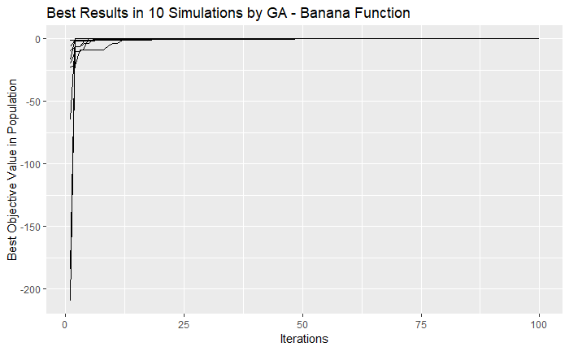

```r
ggplot(data = data.frame(res), aes(x=V1)) +
  geom_line(aes(y=res)) +
  geom_line(aes(y=V3)) +
  geom_line(aes(y=V4)) +
  geom_line(aes(y=V5)) +
  geom_line(aes(y=V6)) +
  geom_line(aes(y=V7)) +
  geom_line(aes(y=V8)) +
  geom_line(aes(y=V9)) +
  geom_line(aes(y=V10)) +
  geom_line(aes(y=V11)) +

  labs(title="Best Results in 10 Simulations by GA - Banana Function", x="Iterations", y="Best Objective Value in Population")
```

```r
opt <- - Inf
for (i in 1:dim(final.obj)[1]) {
  for (j in 1:dim(final.obj)[2]) {
    if (opt < final.obj[i]){
      opt <- final.obj[i]
      x <- final.x[(i-1)*dim(final.obj)[2]+j,]
    }
  }
}
paste('Minimum value in all simulations is:',opt,'at x: [',x[1],',',x[2],']')
```

```
[1] "Minimum value in all simulations is: -5.9545538296263e-08 at x: [ 0.999807856725872 , 0.999630792478514 ]"
```

### Ex3-1.1.3. Observations

- Global minimum was easily found by any inital points, most within 5 iterations.
- Takes more time than gradient-based because GA evaluates objective function more times.

## Ex3-1.2. Eggcrate Function

### Ex3-1.2.1. One Simulation

Parameters used:

- Initial population Size: 20 (default: # of decision variables * 10)
- Nb of iterations: 100 (default)
- Cross over rate: 0.5 (default)
- Mutation rate: 0 (default)
- Elitism number: 0 (default)

NOTE:

- Since GA assumes the objective function is to maximize, the value was negativated.

```r
set.seed(1)
GA.egg <- de(type = "real-valued", fitness = function(x) -eggcrate(x[1],x[2]), lower = c(-2*pi,-2*pi), upper = c(2*pi,2*pi))
```

```
DE | iter = 1 | Mean = -46.059451 | Best =  -3.302073
DE | iter = 2 | Mean = -36.250103 | Best =  -3.302073
DE | iter = 3 | Mean = -27.045640 | Best =  -3.302073
DE | iter = 4 | Mean = -22.277686 | Best =  -3.302073
DE | iter = 5 | Mean = -19.875948321 | Best =  -0.006283534
DE | iter = 6 | Mean = -18.693723054 | Best =  -0.006283534
DE | iter = 7 | Mean = -16.374994942 | Best =  -0.006283534
DE | iter = 8 | Mean = -15.039747502 | Best =  -0.006283534
DE | iter = 9 | Mean = -12.860472150 | Best =  -0.006283534
DE | iter = 10 | Mean = -9.603659173 | Best = -0.006283534
DE | iter = 11 | Mean = -7.007378067 | Best = -0.006283534
DE | iter = 12 | Mean = -5.738982786 | Best = -0.006283534
DE | iter = 13 | Mean = -4.521345171 | Best = -0.006283534
DE | iter = 14 | Mean = -3.517703152 | Best = -0.006283534
DE | iter = 15 | Mean = -2.966897276 | Best = -0.006283534
DE | iter = 16 | Mean = -2.621631863 | Best = -0.006283534
DE | iter = 17 | Mean = -2.155919876 | Best = -0.006283534
DE | iter = 18 | Mean = -1.782939876 | Best = -0.006283534
DE | iter = 19 | Mean = -1.383771763 | Best = -0.006283534
DE | iter = 20 | Mean = -0.627910338 | Best = -0.006283534
DE | iter = 21 | Mean = -0.471979449 | Best = -0.006283534
DE | iter = 22 | Mean = -0.166030187 | Best = -0.006283534
DE | iter = 23 | Mean = -0.130845336 | Best = -0.003708324
DE | iter = 24 | Mean = -0.092551851 | Best = -0.003708324
DE | iter = 25 | Mean = -0.078653833 | Best = -0.001409534
DE | iter = 26 | Mean = -0.0513390511 | Best = -0.0001266653
DE | iter = 27 | Mean = -0.0478350601 | Best = -0.0001266653
DE | iter = 28 | Mean = -0.0277774971 | Best = -0.0001266653
DE | iter = 29 | Mean = -0.0167843608 | Best = -0.0001266653
DE | iter = 30 | Mean = -0.0135048228 | Best = -0.0001266653
DE | iter = 31 | Mean = -0.0113071593 | Best = -0.0001266653
DE | iter = 32 | Mean = -0.0085046816 | Best = -0.0001266653
DE | iter = 33 | Mean = -0.0043117463 | Best = -0.0001266653
DE | iter = 34 | Mean = -0.0033816999 | Best = -0.0001266653
DE | iter = 35 | Mean = -0.0023871753 | Best = -0.0001266653
DE | iter = 36 | Mean = -0.0014259947 | Best = -0.0001266653
DE | iter = 37 | Mean = -7.992200e-04 | Best = -1.670316e-05
DE | iter = 38 | Mean = -5.913271e-04 | Best = -1.670316e-05
DE | iter = 39 | Mean = -4.951169e-04 | Best = -1.670316e-05
DE | iter = 40 | Mean = -3.483711e-04 | Best = -1.670316e-05
```

[output cut: 45 more lines]

```
DE | iter = 86 | Mean = -5.532987e-12 | Best = -8.963001e-15
DE | iter = 87 | Mean = -4.815721e-12 | Best = -8.963001e-15
DE | iter = 88 | Mean = -1.614981e-12 | Best = -8.963001e-15
DE | iter = 89 | Mean = -7.760529e-13 | Best = -8.963001e-15
DE | iter = 90 | Mean = -5.140769e-13 | Best = -8.963001e-15
DE | iter = 91 | Mean = -3.309796e-13 | Best = -8.963001e-15
DE | iter = 92 | Mean = -2.456955e-13 | Best = -8.963001e-15
DE | iter = 93 | Mean = -1.917528e-13 | Best = -8.963001e-15
DE | iter = 94 | Mean = -1.384910e-13 | Best = -7.196472e-15
DE | iter = 95 | Mean = -1.156728e-13 | Best = -7.196472e-15
DE | iter = 96 | Mean = -9.646491e-14 | Best = -7.196472e-15
DE | iter = 97 | Mean = -6.541689e-14 | Best = -1.530765e-15
DE | iter = 98 | Mean = -5.880821e-14 | Best = -1.530765e-15
DE | iter = 99 | Mean = -5.596454e-14 | Best = -1.209657e-16
DE | iter = 100 | Mean = -3.426846e-14 | Best = -1.209657e-16
```

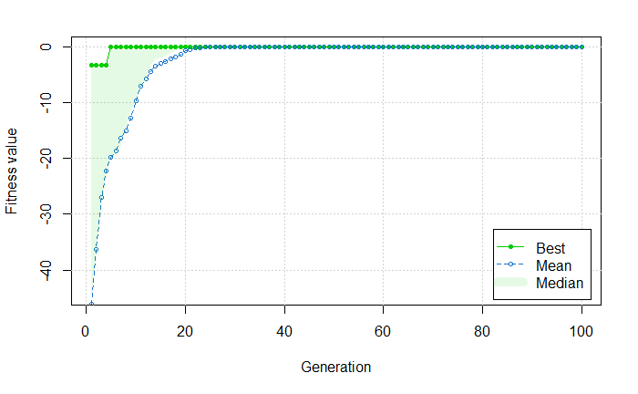

```r
plot(GA.egg)
```

### Ex3-1.2.2. Ten Simulations

```r
time0 <- Sys.time()
for (i in 1:10){
  set.seed(i+1)
  GA.egg.t <- de(type = "real-valued", fitness = function(x) -eggcrate(x[1],x[2]), lower = c(-2*pi,-2*pi), upper = c(2*pi,2*pi),monitor=F)
  if (i==1) {
    res <- GA.egg.t@summary[,"max"]
    final.obj <- GA.egg.t@fitness
    final.x <- GA.egg.t@population
  } else {
    res <- cbind(res,GA.egg.t@summary[,"max"])
    final.obj <- rbind(final.obj,GA.egg.t@fitness)
    final.x <- rbind(final.x,GA.egg.t@population)
  }
}
Sys.time() - time0
```

```
Time difference of 0.756511 secs
```

```r
res <- cbind(seq(1,100),res)
```

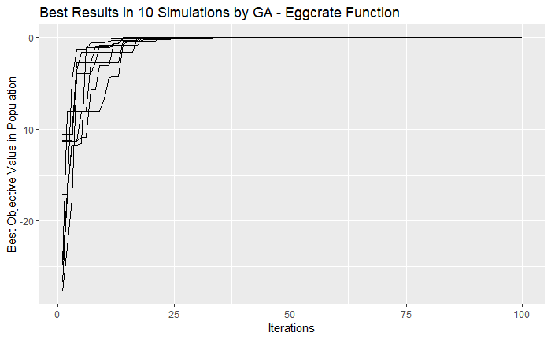

```r
ggplot(data = data.frame(res), aes(x=V1)) +
  geom_line(aes(y=res)) +
  geom_line(aes(y=V3)) +
  geom_line(aes(y=V4)) +
  geom_line(aes(y=V5)) +
  geom_line(aes(y=V6)) +
  geom_line(aes(y=V7)) +
  geom_line(aes(y=V8)) +
  geom_line(aes(y=V9)) +
  geom_line(aes(y=V10)) +
  geom_line(aes(y=V11)) +

  labs(title="Best Results in 10 Simulations by GA - Eggcrate Function", x="Iterations", y="Best Objective Value in Population")
```

```r
opt <- - Inf
for (i in 1:dim(final.obj)[1]) {
  for (j in 1:dim(final.obj)[2]) {
    if (opt < final.obj[i]){
      opt <- final.obj[i]
      x <- final.x[(i-1)*dim(final.obj)[2]+j,]
    }
  }
}
paste('Minimum value in all simulations is:',opt,'at x: [',x[1],',',x[2],']')
```

```
[1] "Minimum value in all simulations is: -2.00035306488637e-15 at x: [ 8.74208681139224e-09 , -7.15943100996995e-10 ]"
```

### Ex3-1.2.3. Observations

- Global minimum was easily found by any inital points, most within 25 iterations.
- This is comparably good performance against gradient-based which does not guarantee the global minimum in any initial points.
- Takes more time than gradient-based because GA evaluates objective function more times.

## Ex3-1.3. Golinski’s Speed Reducer

### Ex3-1.3.1. One Simulation

Parameters used:

- Initial population Size: 70 (default: # of decision variables * 10)
- Nb of iterations: 100 (default)
- Cross over rate: 0.5 (default)
- Mutation rate: 0 (default)
- Elitism number: 2
  - This parameter was most important and should be small.

NOTE:

- Since GA assumes the objective function is to maximize, the value was negativated.
- Set the penalty term to the objective function as +10^5*delta to off-constraint solution, where delta represents absolute distances from constraint boudaries.

```r
set.seed(1)
fitness <- function(x){
  -golSR(x[1],x[2],x[3],x[4],x[5],x[6],x[7])+constGSRdist(x[1],x[2],x[3],x[4],x[5],x[6],x[7])*100000
}

set.seed(1)
GA.gsr <- de(type = "real-valued", fitness = fitness,
             lower = c(2.6, 0.7, 17, 7.3, 7.3, 2.9, 5.0),
             upper = c(3.6, 0.8, 28, 8.3, 8.3, 3.9, 5.5),
             elitism = 2
             )
```

```
DE | iter = 1 | Mean = -42204.07 | Best = -11698.72
DE | iter = 2 | Mean = -32436.766 | Best =  -9351.798
DE | iter = 3 | Mean = -26327.102 | Best =  -9351.798
DE | iter = 4 | Mean = -21993.609 | Best =  -5274.605
DE | iter = 5 | Mean = -18905.526 | Best =  -5274.605
DE | iter = 6 | Mean = -15746.569 | Best =  -4345.179
DE | iter = 7 | Mean = -13502.097 | Best =  -3857.788
DE | iter = 8 | Mean = -12063.276 | Best =  -3518.399
DE | iter = 9 | Mean = -10451.721 | Best =  -3518.399
DE | iter = 10 | Mean = -9145.590 | Best = -3518.399
DE | iter = 11 | Mean = -8206.301 | Best = -3518.399
DE | iter = 12 | Mean = -7469.991 | Best = -3518.399
DE | iter = 13 | Mean = -6727.081 | Best = -3491.747
DE | iter = 14 | Mean = -6240.866 | Best = -3491.747
DE | iter = 15 | Mean = -5738.641 | Best = -3280.637
DE | iter = 16 | Mean = -5236.283 | Best = -3280.637
DE | iter = 17 | Mean = -4814.309 | Best = -3217.000
DE | iter = 18 | Mean = -4397.368 | Best = -3217.000
DE | iter = 19 | Mean = -4123.160 | Best = -3179.501
DE | iter = 20 | Mean = -3843.883 | Best = -3179.501
DE | iter = 21 | Mean = -3628.948 | Best = -3179.501
DE | iter = 22 | Mean = -3515.126 | Best = -3114.665
DE | iter = 23 | Mean = -3443.246 | Best = -3091.247
DE | iter = 24 | Mean = -3394.270 | Best = -3091.247
DE | iter = 25 | Mean = -3350.233 | Best = -3091.247
DE | iter = 26 | Mean = -3311.283 | Best = -3091.247
DE | iter = 27 | Mean = -3285.989 | Best = -3091.247
DE | iter = 28 | Mean = -3257.337 | Best = -3080.637
DE | iter = 29 | Mean = -3237.870 | Best = -3080.637
DE | iter = 30 | Mean = -3217.653 | Best = -3074.840
DE | iter = 31 | Mean = -3194.816 | Best = -3073.087
DE | iter = 32 | Mean = -3172.137 | Best = -3059.654
DE | iter = 33 | Mean = -3155.552 | Best = -3059.654
DE | iter = 34 | Mean = -3138.647 | Best = -3059.654
DE | iter = 35 | Mean = -3123.082 | Best = -3059.654
DE | iter = 36 | Mean = -3109.723 | Best = -3059.654
DE | iter = 37 | Mean = -3100.361 | Best = -3055.699
DE | iter = 38 | Mean = -3094.779 | Best = -3052.771
DE | iter = 39 | Mean = -3088.984 | Best = -3041.512
DE | iter = 40 | Mean = -3082.658 | Best = -3041.512
```

[output cut: 45 more lines]

```
DE | iter = 86 | Mean = -2999.487 | Best = -2997.185
DE | iter = 87 | Mean = -2999.178 | Best = -2997.185
DE | iter = 88 | Mean = -2998.931 | Best = -2997.090
DE | iter = 89 | Mean = -2998.705 | Best = -2996.987
DE | iter = 90 | Mean = -2998.483 | Best = -2996.987
DE | iter = 91 | Mean = -2998.181 | Best = -2996.775
DE | iter = 92 | Mean = -2997.957 | Best = -2996.321
DE | iter = 93 | Mean = -2997.807 | Best = -2996.321
DE | iter = 94 | Mean = -2997.584 | Best = -2996.321
DE | iter = 95 | Mean = -2997.437 | Best = -2996.040
DE | iter = 96 | Mean = -2997.304 | Best = -2996.040
DE | iter = 97 | Mean = -2997.122 | Best = -2995.970
DE | iter = 98 | Mean = -2996.975 | Best = -2995.870
DE | iter = 99 | Mean = -2996.858 | Best = -2995.783
DE | iter = 100 | Mean = -2996.732 | Best = -2995.783
```

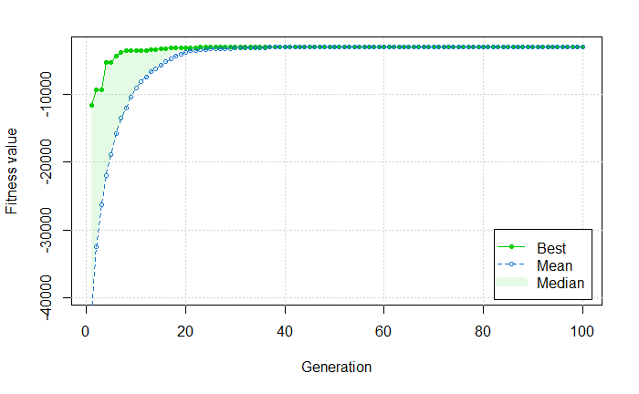

```r
plot(GA.gsr)
```

### Ex3-1.3.2. Ten Simulations

```r
time0 <- Sys.time()
for (i in 1:10){
  set.seed(i+1)
  GA.golSR.t <- de(type = "real-valued", fitness = fitness,
             lower = c(2.6, 0.7, 17, 7.3, 7.3, 2.9, 5.0),
             upper = c(3.6, 0.8, 28, 8.3, 8.3, 3.9, 5.5),
             elitism = 2
             ,monitor=F)
  if (i==1) {
    res <- GA.golSR.t@summary[,"max"]
    final.obj <- GA.golSR.t@fitness
    final.x <- GA.golSR.t@population
  } else {
    res <- cbind(res,GA.golSR.t@summary[,"max"])
    final.obj <- rbind(final.obj,GA.golSR.t@fitness)
    final.x <- rbind(final.x,GA.golSR.t@population)
  }
}
Sys.time() - time0
```

```
Time difference of 6.033823 secs
```

```r
cntAll <- c()
for (i in 1:700){
  cntAll <- c(cntAll, constGSRcnt(final.x[i,1],final.x[i,2],
                                  final.x[i,3],final.x[i,4],
                                  final.x[i,5],final.x[i,6],
                                  final.x[i,7]))
}
```

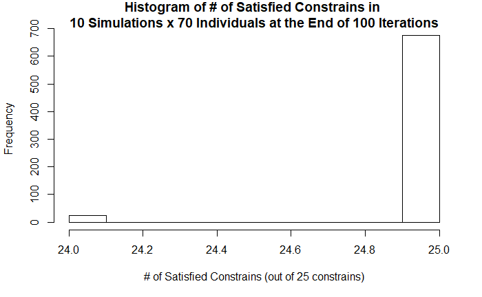

```r
hist(cntAll, main="Histogram of # of Satisfied Constrains in \n10 Simulations x 70 Individuals at the End of 100 Iterations"
     ,xlab = "# of Satisfied Constrains (out of 25 constrains)")
```

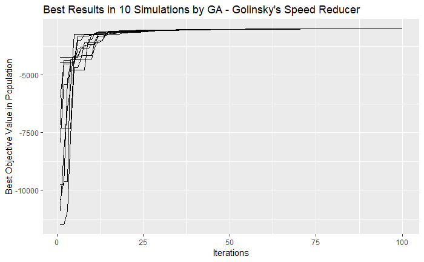

```r
res <- cbind(seq(1,100),res)
ggplot(data = data.frame(res), aes(x=V1)) +
  geom_line(aes(y=res)) +
  geom_line(aes(y=V3)) +
  geom_line(aes(y=V4)) +
  geom_line(aes(y=V5)) +
  geom_line(aes(y=V6)) +
  geom_line(aes(y=V7)) +
  geom_line(aes(y=V8)) +
  geom_line(aes(y=V9)) +
  geom_line(aes(y=V10)) +
  geom_line(aes(y=V11)) +

  labs(title="Best Results in 10 Simulations by GA - Golinsky's Speed Reducer", x="Iterations", y="Best Objective Value in Population")
```

```r
opt <- - Inf
for (i in 1:dim(final.obj)[1]) {
  for (j in 1:dim(final.obj)[2]) {
    if (opt < final.obj[i]){
      opt <- final.obj[i]
      x <- final.x[(i-1)*dim(final.obj)[2]+j,]
    }
  }
}
paste('Minimum value in all simulations is:',opt,'at x: [',x[1],',',x[2],',',x[3],',',x[4],',',x[5],',',x[6],',',x[7],']')
```

```
[1] "Minimum value in all simulations is: -2995.19041008523 at x: [ 3.50051945041036 , 0.700000782696726 , 17.0013684227151 , 7.31165960921914 , 7.71758022399795 , 3.35029234058328 , 5.28699946494457 ]"
```

```r
paste('Number of satisfied constrains is',constGSRcnt(x[1],x[2],x[3],x[4],x[5],x[6],x[7]),'out of 25 constrains.')
```

```
[1] "Number of satisfied constrains is 25 out of 25 constrains."
```

#### Forcing x3 as integer:

```r
paste('Minimum value in all simulations is:',opt,'at x: [',x[1],',',x[2],',',as.integer(x[3]),',',x[4],',',x[5],',',x[6],',',x[7],']')
```

```
[1] "Minimum value in all simulations is: -2995.19041008523 at x: [ 3.50051945041036 , 0.700000782696726 , 17 , 7.31165960921914 , 7.71758022399795 , 3.35029234058328 , 5.28699946494457 ]"
```

```r
paste('Number of satisfied constrains is',constGSRcnt(x[1],x[2],as.integer(x[3]),x[4],x[5],x[6],x[7]),'out of 25 constrains.')
```

```
[1] "Number of satisfied constrains is 25 out of 25 constrains."
```

### Ex3-1.3.3. Observations

- All simulations found on-constraint solutions and the global minimum.
- Comparably much better and more stable performance against gradient-based.
- More times of evaluating objective functions than gradient-based.

# Ex3-2. Particle Swarm Optimization

```r
library(pso)
```

## Ex3-2.1. Banana Function

### Ex3-2.1.1. One Simulation

Parameters used:

- Population Size: 12 (default)
- Nb of Iterations : 100,
- Exploitation constant: 0.7213 (default)
- Local Exploration constant: 1.193 (default)
- Global Exploration constant: 1.193 (default)

```r
set.seed(1)
PSO.banana <- psoptim(c(NA,NA), fn = function(x) banana(x[1],x[2]), lower = c(-5, -5),
                      upper = c(5, 5),
                      control = list(trace = 1, REPORT=1, maxit = 100, trace.stats=T))
```

```
S=12, K=3, p=0.2297, w0=0.7213, w1=0.7213, c.p=1.193, c.g=1.193
v.max=NA, d=14.14, vectorize=FALSE, hybrid=off
It 1: fitness=4.743
It 2: fitness=3.912
It 3: fitness=3.912
It 4: fitness=0.9631
It 5: fitness=0.7898
It 6: fitness=0.7898
It 7: fitness=0.132
It 8: fitness=0.132
It 9: fitness=0.132
It 10: fitness=0.132
It 11: fitness=0.132
It 12: fitness=0.132
It 13: fitness=0.132
It 14: fitness=0.132
It 15: fitness=0.132
It 16: fitness=0.132
It 17: fitness=0.132
It 18: fitness=0.132
It 19: fitness=0.132
It 20: fitness=0.132
It 21: fitness=0.02731
It 22: fitness=0.02731
It 23: fitness=0.02731
It 24: fitness=0.02731
It 25: fitness=0.02731
It 26: fitness=0.02731
It 27: fitness=0.02731
It 28: fitness=0.02731
It 29: fitness=0.02731
It 30: fitness=0.02731
It 31: fitness=0.02731
It 32: fitness=0.02731
It 33: fitness=0.02731
It 34: fitness=0.02731
It 35: fitness=0.005627
It 36: fitness=0.005627
It 37: fitness=0.005627
It 38: fitness=0.005627
```

[output cut: 48 more lines]

```
It 87: fitness=0.004165
It 88: fitness=0.004165
It 89: fitness=0.004112
It 90: fitness=0.004112
It 91: fitness=0.004112
It 92: fitness=0.004112
It 93: fitness=0.004097
It 94: fitness=0.004097
It 95: fitness=0.004097
It 96: fitness=0.004097
It 97: fitness=0.004097
It 98: fitness=0.004097
It 99: fitness=0.004097
It 100: fitness=0.004097
Maximal number of iterations reached
```

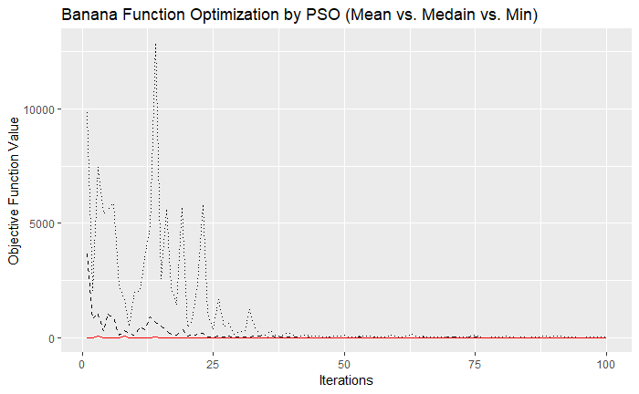

```r
df <- data.frame(PSO.banana$stats$f)
names = seq(1,dim(df)[2])*1
colnames(df) <- names

d.median <- data.frame(Median=sapply(df,median))
d.mean <- data.frame(Mean=sapply(df,mean))
d.min <- data.frame(Min=sapply(df,min))
d <- data.frame(Iterations=names, Median=d.median, Mean=d.mean, Min=d.min)

ggplot(data = d, aes(x=Iterations)) +
  geom_line(aes(y = Median),linetype = "dashed") +
  geom_line(aes(y = Mean), linetype = "dotted") +
  geom_line(aes(y = Min), color="red") +
  labs(title="Banana Function Optimization by PSO (Mean vs. Medain vs. Min)", x="Iterations", y="Objective Function Value")
```

### Ex3-2.1.2. Ten Simulations

```r
time0 <- Sys.time()
for (i in 1:10){
  set.seed(i+1)
  PSO.banana.t <- psoptim(c(NA,NA), fn = function(x) banana(x[1],x[2]), lower = c(-5, -5),
                      upper = c(5, 5),
                      control = list(trace = 1, REPORT=1, maxit = 100, trace.stats=T))
  df <- data.frame(PSO.banana.t$stats$f)
  names = seq(1,dim(df)[2])*1
  colnames(df) <- names
  res.t <- data.frame(sapply(df,min))

  if (i==1){
    res <- data.frame(res.t)
    final.obj <- PSO.banana.t$stats$f[100]
    final.x <- PSO.banana.t$stats$x[100]
  } else {
    res <- data.frame(res,res.t)
    final.obj <- rbind(final.obj, PSO.banana.t$stats$f[100])
    final.x <- rbind(final.x, PSO.banana.t$stats$x[100])
  }
}
time1 <- Sys.time()
res <- data.frame(x=seq(1,100),res)
```

```r
time1 - time0
```

```
Time difference of 1.657074 secs
```

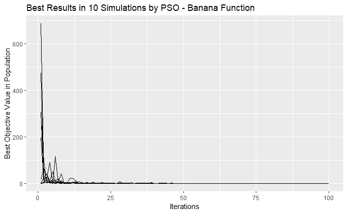

```r
ggplot(data = res, aes(x=x)) +
  geom_line(aes(y=sapply.df..min.)) +
  geom_line(aes(y=sapply.df..min..1)) +
  geom_line(aes(y=sapply.df..min..2)) +
  geom_line(aes(y=sapply.df..min..3)) +
  geom_line(aes(y=sapply.df..min..4)) +
  geom_line(aes(y=sapply.df..min..5)) +
  geom_line(aes(y=sapply.df..min..6)) +
  geom_line(aes(y=sapply.df..min..7)) +
  geom_line(aes(y=sapply.df..min..8)) +
  geom_line(aes(y=sapply.df..min..9)) +

  labs(title="Best Results in 10 Simulations by PSO - Banana Function", x="Iterations", y="Best Objective Value in Population")
```

```r
opt <- Inf
for (i in 1:10) {
  for (j in 1:12) {
    if (opt > final.obj[[i]][j]){
      opt <- final.obj[[i]][j]
      x <- final.x[[i]][,j]
    }
  }
}
paste('Minimum value in all simulations is:',opt,'at x: [',x[1],',',x[2],']')
```

```
[1] "Minimum value in all simulations is: 1.92684031170323e-06 at x: [ 1.00138426168869 , 1.00276011488399 ]"
```

### Ex3-2.1.3. Observations

- Global minimum was easily found by any inital points, most within 10 iterations.
- Takes more time than gradient-based because PSO evaluates objective function more times.
- Takes more time than GA.

## Ex3-2.2. Eggcrate Function

### Ex3-2.2.1. One Simulation

Parameters used:

- Population Size: 12 (default)
- Nb of Iterations : 100
- Exploitation constant: 0.7213 (default)
- Local Exploration constant: 1.193 (default)
- Global Exploration constant: 1.193 (default)

```r
set.seed(1)
PSO.eggcrate <- psoptim(c(NA,NA), fn = function(x) eggcrate(x[1],x[2]), lower = c(-5, -5),
                      upper = c(5, 5),
                      control = list(REPORT = 1, trace = 1, maxit = 100, trace.stats=T))
```

```
S=12, K=3, p=0.2297, w0=0.7213, w1=0.7213, c.p=1.193, c.g=1.193
v.max=NA, d=14.14, vectorize=FALSE, hybrid=off
It 1: fitness=11.89
It 2: fitness=7.295
It 3: fitness=7.295
It 4: fitness=5.97
It 5: fitness=2.872
It 6: fitness=2.872
It 7: fitness=2.815
It 8: fitness=2.403
It 9: fitness=2.403
It 10: fitness=2.403
It 11: fitness=2.403
It 12: fitness=2.403
It 13: fitness=2.403
It 14: fitness=2.403
It 15: fitness=2.403
It 16: fitness=1.089
It 17: fitness=1.089
It 18: fitness=1.089
It 19: fitness=0.2293
It 20: fitness=0.2293
It 21: fitness=0.2293
It 22: fitness=0.2293
It 23: fitness=0.2293
It 24: fitness=0.2293
It 25: fitness=0.02647
It 26: fitness=0.02647
It 27: fitness=0.02647
It 28: fitness=0.02647
It 29: fitness=0.02647
It 30: fitness=0.02647
It 31: fitness=0.02475
It 32: fitness=0.001253
It 33: fitness=0.001253
It 34: fitness=0.001253
It 35: fitness=0.001253
It 36: fitness=0.001253
It 37: fitness=0.001253
It 38: fitness=0.001253
```

[output cut: 48 more lines]

```
It 87: fitness=1.525e-08
It 88: fitness=1.525e-08
It 89: fitness=1.525e-08
It 90: fitness=5.414e-09
It 91: fitness=5.414e-09
It 92: fitness=5.414e-09
It 93: fitness=4.238e-09
It 94: fitness=1.915e-10
It 95: fitness=1.915e-10
It 96: fitness=1.915e-10
It 97: fitness=9.958e-11
It 98: fitness=9.958e-11
It 99: fitness=9.958e-11
It 100: fitness=9.958e-11
Maximal number of iterations reached
```

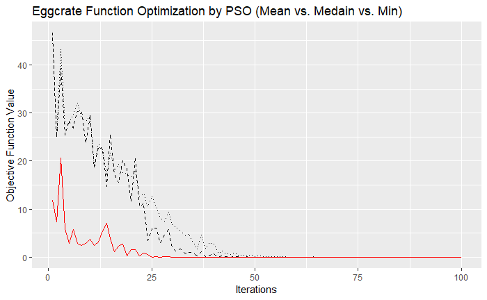

```r
df <- data.frame(PSO.eggcrate$stats$f)
names = seq(1,dim(df)[2])*1
colnames(df) <- names

d.median <- data.frame(Median=sapply(df,median))
d.mean <- data.frame(Mean=sapply(df,mean))
d.min <- data.frame(Min=sapply(df,min))
d <- data.frame(Iterations=names, Median=d.median, Mean=d.mean, Min=d.min)

ggplot(data = d, aes(x=Iterations)) +
  geom_line(aes(y = Median),linetype = "dashed") +
  geom_line(aes(y = Mean), linetype = "dotted") +
  geom_line(aes(y = Min), color="red") +
  labs(title="Eggcrate Function Optimization by PSO (Mean vs. Medain vs. Min)", x="Iterations", y="Objective Function Value")
```

### Ex3-2.2.2. Ten Simulations

```r
time0 <- Sys.time()
for (i in 1:10){
  set.seed(i+1)
  PSO.egg.t <- psoptim(c(NA,NA), fn = function(x) eggcrate(x[1],x[2]), lower = c(-5, -5),
                      upper = c(5, 5),
                      control = list(REPORT = 1, trace = 1, maxit = 100, trace.stats=T))
  df <- data.frame(PSO.egg.t$stats$f)
  names = seq(1,dim(df)[2])*1
  colnames(df) <- names
  res.t <- data.frame(sapply(df,min))

  if (i==1){
    res <- data.frame(res.t)
    final.obj <- PSO.egg.t$stats$f[100]
    final.x <- PSO.egg.t$stats$x[100]
  } else {
    res <- data.frame(res,res.t)
    final.obj <- rbind(final.obj, PSO.egg.t$stats$f[100])
    final.x <- rbind(final.x, PSO.egg.t$stats$x[100])
  }
}
time1 <- Sys.time()
res <- data.frame(x=seq(1,100),res)
```

```r
time1 - time0
```

```
Time difference of 1.910935 secs
```

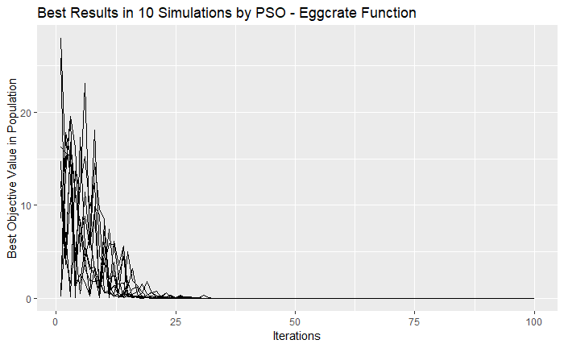

```r
ggplot(data = res, aes(x=x)) +
  geom_line(aes(y=sapply.df..min.)) +
  geom_line(aes(y=sapply.df..min..1)) +
  geom_line(aes(y=sapply.df..min..2)) +
  geom_line(aes(y=sapply.df..min..3)) +
  geom_line(aes(y=sapply.df..min..4)) +
  geom_line(aes(y=sapply.df..min..5)) +
  geom_line(aes(y=sapply.df..min..6)) +
  geom_line(aes(y=sapply.df..min..7)) +
  geom_line(aes(y=sapply.df..min..8)) +
  geom_line(aes(y=sapply.df..min..9)) +

  labs(title="Best Results in 10 Simulations by PSO - Eggcrate Function", x="Iterations", y="Best Objective Value in Population")
```

```r
opt <- Inf
for (i in 1:10) {
  for (j in 1:12) {
    if (opt > final.obj[[i]][j]){
      opt <- final.obj[[i]][j]
      x <- final.x[[i]][,j]
    }
  }
}
paste('Minimum value in all simulations is:',opt,'at x: [',x[1],',',x[2],']')
```

```
[1] "Minimum value in all simulations is: 6.3391171070681e-11 at x: [ 1.3721348919341e-06 , -7.45230033342191e-07 ]"
```

### Ex3-2.2.3. Observations

- Global minimum was easily found by any inital points, most within 25 iterations.
- Takes more time than gradient-based because PSO evaluates objective function more times.
- Takes more time than GA.

## Ex3-2.3. Golinsky’s Speed Reducer

### Ex3-2.3.1. One Simulation

Parameters used:

- Population Size: 70
  - This parameter was most important and drove the convergence.
- Nb of Iterations : 100
- Exploitation constant: 0.7213 (default)
- Local Exploration constant: 1.193 (default)
- Global Exploration constant: 1.193 (default)

NOTE:

- Set the penalty term to the objective function as +10^5*delta to off-constraint solution, where delta represents absolute distances from constraint boudaries.

```r
set.seed(1)
fitness <- function(x){
  golSR(x[1],x[2],x[3],x[4],x[5],x[6],x[7])-constGSRdist(x[1],x[2],x[3],x[4],x[5],x[6],x[7])*100000
}
PSO.golSR <- psoptim(rep(NA,7), fn = fitness,
                      lower = c(2.6, 0.7, 17, 7.3, 7.3, 2.9, 5.0),
                      upper = c(3.6, 0.8, 28, 8.3, 8.3, 3.9, 5.5),
                      control = list(trace = 1, maxit = 100, s=70,
                                     REPORT=1,trace.stats=T))
```

```
S=70, K=3, p=0.04225, w0=0.7213, w1=0.7213, c.p=1.193, c.g=1.193
v.max=NA, d=11.19, vectorize=FALSE, hybrid=off
It 1: fitness=13420
It 2: fitness=4737
It 3: fitness=3968
It 4: fitness=3241
It 5: fitness=3095
It 6: fitness=3065
It 7: fitness=3061
It 8: fitness=3061
It 9: fitness=3061
It 10: fitness=3055
It 11: fitness=3052
It 12: fitness=3052
It 13: fitness=3052
It 14: fitness=3052
It 15: fitness=3046
It 16: fitness=3046
It 17: fitness=3033
It 18: fitness=3033
It 19: fitness=3033
It 20: fitness=3029
It 21: fitness=3022
It 22: fitness=3022
It 23: fitness=3012
It 24: fitness=3012
It 25: fitness=3012
It 26: fitness=3012
It 27: fitness=3008
It 28: fitness=3008
It 29: fitness=3008
It 30: fitness=3008
It 31: fitness=3008
It 32: fitness=3006
It 33: fitness=3006
It 34: fitness=3006
It 35: fitness=3006
It 36: fitness=3006
It 37: fitness=3006
It 38: fitness=3004
```

[output cut: 48 more lines]

```
It 87: fitness=2995
It 88: fitness=2995
It 89: fitness=2995
It 90: fitness=2995
It 91: fitness=2995
It 92: fitness=2995
It 93: fitness=2995
It 94: fitness=2995
It 95: fitness=2995
It 96: fitness=2995
It 97: fitness=2995
It 98: fitness=2995
It 99: fitness=2995
It 100: fitness=2995
Maximal number of iterations reached
```

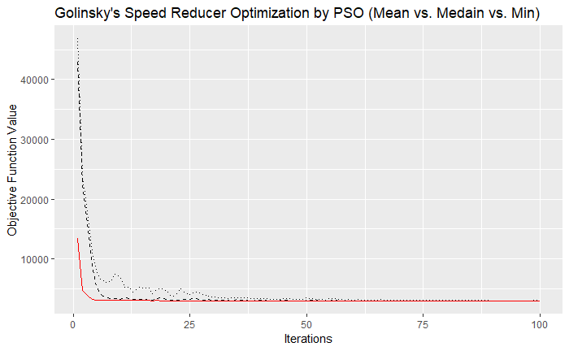

```r
df <- data.frame(PSO.golSR$stats$f)
names = seq(1,dim(df)[2])*1
colnames(df) <- names

d.median <- data.frame(Median=sapply(df,median))
d.mean <- data.frame(Mean=sapply(df,mean))
d.min <- data.frame(Min=sapply(df,min))
d <- data.frame(Iterations=names, Median=d.median, Mean=d.mean, Min=d.min)

ggplot(data = d, aes(x=Iterations)) +
  geom_line(aes(y = Median),linetype = "dashed") +
  geom_line(aes(y = Mean), linetype = "dotted") +
  geom_line(aes(y = Min), color="red") +
  labs(title="Golinsky's Speed Reducer Optimization by PSO (Mean vs. Medain vs. Min)", x="Iterations", y="Objective Function Value")
```

### Ex3-2.3.2. Ten Simulations

```r
time0 <- Sys.time()
for (i in 1:10){
  set.seed(i+1)
  PSO.golSR.t <- psoptim(rep(NA,7), fn = fitness,
                      lower = c(2.6, 0.7, 17, 7.3, 7.3, 2.9, 5.0),
                      upper = c(3.6, 0.8, 28, 8.3, 8.3, 3.9, 5.5),
                      control = list(trace = 1, maxit = 100, s=70,
                                     REPORT=1,trace.stats=T))
  df <- data.frame(PSO.golSR.t$stats$f)
  names = seq(1,dim(df)[2])*1
  colnames(df) <- names
  res.t <- data.frame(sapply(df,min))

  if (i==1){
    res <- data.frame(res.t)
    final.obj <- PSO.golSR.t$stats$f[100]
    final.x <- PSO.golSR.t$stats$x[100]
  } else {
    res <- data.frame(res,res.t)
    final.obj <- rbind(final.obj, PSO.golSR.t$stats$f[100])
    final.x <- rbind(final.x, PSO.golSR.t$stats$x[100])
  }
}
time1 <- Sys.time()
res <- data.frame(x=seq(1,100),res)
```

```r
time1 - time0
```

```
Time difference of 9.044152 secs
```

```r
cntAll <- c()
for (i in 1:10){
  for (j in 1:70){
  cntAll <- c(cntAll, constGSRcnt(final.x[[i]][1,j],final.x[[i]][2,j],final.x[[i]][3,j],
                                  final.x[[i]][4,j],final.x[[i]][5,j],final.x[[i]][6,j],
                                  final.x[[i]][7,j]))
  }
}
```

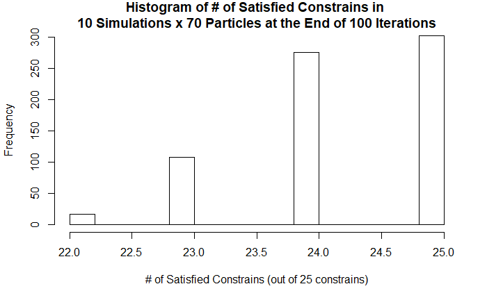

```r
hist(cntAll, main="Histogram of # of Satisfied Constrains in \n10 Simulations x 70 Particles at the End of 100 Iterations"
     ,xlab = "# of Satisfied Constrains (out of 25 constrains)")
```

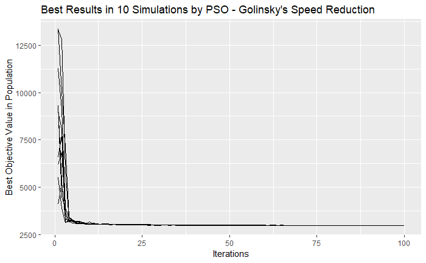

```r
ggplot(data = res, aes(x=x)) +
  geom_line(aes(y=sapply.df..min.)) +
  geom_line(aes(y=sapply.df..min..1)) +
  geom_line(aes(y=sapply.df..min..2)) +
  geom_line(aes(y=sapply.df..min..3)) +
  geom_line(aes(y=sapply.df..min..4)) +
  geom_line(aes(y=sapply.df..min..5)) +
  geom_line(aes(y=sapply.df..min..6)) +
  geom_line(aes(y=sapply.df..min..7)) +
  geom_line(aes(y=sapply.df..min..8)) +
  geom_line(aes(y=sapply.df..min..9)) +

  labs(title="Best Results in 10 Simulations by PSO - Golinsky's Speed Reduction", x="Iterations", y="Best Objective Value in Population")
```

```r
opt <- Inf
for (i in 1:10) {
  for (j in 1:70) {
    if (opt > final.obj[[i]][j]){
      opt <- final.obj[[i]][j]
      x <- final.x[[i]][,j]
    }
  }
}
paste('Minimum value in all simulations is:',opt,'at x: [',x[1],',',x[2],',',x[3],',',x[4],',',x[5],',',x[6],',',x[7],',',']')
```

```
[1] "Minimum value in all simulations is: 2994.52919799405 at x: [ 3.50002834010537 , 0.700003786595843 , 17 , 7.30814434106966 , 7.71589031850017 , 3.35029641406264 , 5.28671866585811 , ]"
```

```r
paste('Number of satisfied constrains is',constGSRcnt(x[1],x[2],x[3],x[4],x[5],x[6],x[7]),'out of 25 constrains.')
```

```
[1] "Number of satisfied constrains is 25 out of 25 constrains."
```

### Ex3-2.3.3. Observations

- All simulations found on-constraint solutions and the global minimum.
- Comparably much better and more stable performance against gradient-based.
- More times of evaluating objective functions than gradient-based.
- Compuatation time was a little longer than GA.
- Faster convergence than GA but less power to keep solution within constraints.